# HW4_guide

shutian

2023/10/16

### 二项分布

有关二项分布的介绍可参考：https://zhuanlan.zhihu.com/p/145930394

了解并使用rbinom，dbinom，pbinom，qbinom

`rbinom(n, size, prob)`,用于从给定样本中为给定概率生成所需数量的随机值,产生n个b(size, prob)的二项分布随机数

```r
?rbinom
```

```
## 打开httpd帮助服务器… 好了
```

```r
rbinom(n = 10, size = 1, p = 0.5)
```

```
##  [1] 0 1 0 0 1 1 1 0 0 1
```

```r
rbinom(n = 10, size = 10, p = 0.5)
```

```
##  [1] 2 5 3 4 8 6 5 6 4 6
```

`dbinom(x, size, prob)`,计算每个点x(可以是向量)的概率质量分布

```r
# 进行5次bernoulli实验，2次成功的概率
dbinom(2,5,0.6)
```

```
## [1] 0.2304
```

```r
# 支持向量式输入
dbinom(c(0,2,4),5,0.6)
```

```
## [1] 0.01024 0.23040 0.25920
```

```r
dbinom(1:4,5,0.6)
```

```
## [1] 0.0768 0.2304 0.3456 0.2592
```

`pbinom(x, size, prob)`,计算每个点x的在特定二项分布下的累计概率分布

```r
# 观察数据规律
dbinom(0:1,5,0.6)
```

```
## [1] 0.01024 0.07680
```

```r
pbinom(1,5,0.6)
```

```
## [1] 0.08704
```

```r
# 同样支持向量输入
dbinom(0:3,5,0.6)
```

```
## [1] 0.01024 0.07680 0.23040 0.34560
```

```r
pbinom(0:3,5,0.6)
```

```
## [1] 0.01024 0.08704 0.31744 0.66304
```

```r
# 对于累计求和，r语言还带了其他函数cumsum可以进行求和
a = dbinom(0:3,5,0.6)
(b = cumsum(a))
```

```
## [1] 0.01024 0.08704 0.31744 0.66304
```

```r
# 既然可以求差，同样我们可以利用r语言一些自带的函数来求彼此之间的差异
diff(1:5)
```

```
## [1] 1 1 1 1
```

```r
diff(c(0,b))
```

```
## [1] 0.01024 0.07680 0.23040 0.34560
```

`qbinom(x, size, prob)`,计算二项式分布的逆累积分布函数

```r
dbinom(0:5,5,0.6)
```

```
## [1] 0.01024 0.07680 0.23040 0.34560 0.25920 0.07776
```

```r
pbinom(0:5,5,0.6)
```

```
## [1] 0.01024 0.08704 0.31744 0.66304 0.92224 1.00000
```

```r
qbinom(0.47,5,0.6)
```

```
## [1] 3
```

```r
qbinom(0.30,5,0.6)
```

```
## [1] 2
```

现在，让我们来看一些有关二项分布的例子：

```r
#投掷3枚骰子，1朝上概率是1/6，B(3,1/6)
N = 3
p = 1/6
mydata <- (data.frame(num = 0:N, pmf = dbinom(0:N, N, p), cdf = pbinom(0:N, N, p)))

#投掷3个骰子，恰好1个是数字1朝上
dbinom(1,N,p)
```

```
## [1] 0.3472222
```

```r
factorial(N)/factorial(1)/factorial(N-1)*(p)^1*(1-p)^2
```

```
## [1] 0.3472222
```

```r
#投掷3个骰子，不超过（小于等于）1个是数字1朝上
dbinom(0,N,p) + dbinom(1,N,p)
```

```
## [1] 0.9259259
```

```r
pbinom(1,N,p)
```

```
## [1] 0.9259259
```

```r
#期望：
attach(mydata) #解释一下这里
(E_X = sum(num*pmf))
```

```
## [1] 0.5
```

```r
N*p
```

```
## [1] 0.5
```

```r
#方差：
(Var_X = sum(num ^ 2 * pmf) - E_X ^ 2)
```

```
## [1] 0.4166667
```

```r
N*p*(1-p)
```

```
## [1] 0.4166667
```

```r
detach(mydata)
```

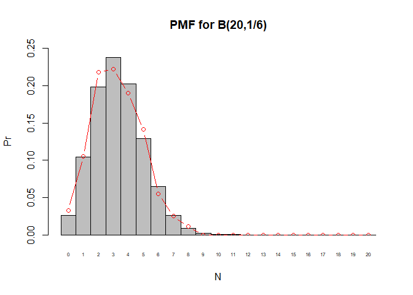

```r
#投掷20个骰子，数字1朝上次数的分布列(理论值)
n = 20
p = 1/6
df <- (data.frame(num = 0:n, pmf = dbinom(0:n, n, p), cdf = pbinom(0:n, n, p)))

#理论和经验PMF
barplot(df$pmf, width = 1, space = 0,
        names.arg = c(0:20), cex.names = 0.5, ylim = c(0,0.25),
        main = 'PMF for B(20,1/6)', xlab = 'N', ylab = 'Pr') #理论值
samp <- rbinom(1000,n,p) #抽样1000次
r <- hist(samp, breaks = c(0:21-0.5),plot = F) #经验数据
lines(r$breaks[2:22], r$density,type = 'b', col = 'red')
```

### 正态分布

```r
# x可以是数值
rnorm(5,0,1)
```

```
## [1] -0.737683525 -0.812533772  0.637845447 -0.169426851  0.005057941
```

```r
# 同样x可以是向量，此时返回向量长度的数值
a = 1:6
rnorm(a,15,2)
```

```
## [1] 14.18170 16.97189 14.94459 13.22464 16.68856 16.00853
```

`dnorm(x,mean,sd)`,返回均值为mean，标准差为sd在x处的概率密度值

```r
dnorm(2,2,1)
```

```
## [1] 0.3989423
```

```r
# 同样接受向量化输入
dnorm(c(0,1),0,1)
```

```
## [1] 0.3989423 0.2419707
```

`pnorm(x,mean,sd)`,返回均值为mean，标准差为sd在x处的累计概率密度

```r
pnorm(0,0,1)
```

```
## [1] 0.5
```

`qnorm(x,mean,sd)`,返回均值为mean，标准差为sd在累计概率密度为x处对应的数值

```r
qnorm(0.5,0,1)
```

```
## [1] 0
```

```r
qnorm(0.975,0,1)
```

```
## [1] 1.959964
```

现在，让我们演示一下有关正态分布的pdf的例子：

```r
dnorm(2) #f(x) = 1/sqrt(2*pi) * exp(-x^2/2)
```

```
## [1] 0.05399097
```

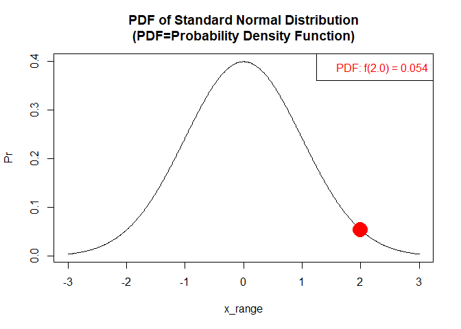

```r
dnorm_demo <- function(x, n = 3){
  x_range = seq(-n,n,0.01)
  plot(x_range,dnorm(x_range),type = 'l', ylab = 'Pr',
     main = 'PDF of Standard Normal Distribution\n(PDF=Probability Density Function)')
  points(x,dnorm(x),col = 'red', pch = 16, cex = 3)
  legend('topright',sprintf('PDF: f(%.1f) = %.3f', x,dnorm(x)), text.col = 'red')
}
dnorm_demo(2)
```

接下来是有关cdf的演示

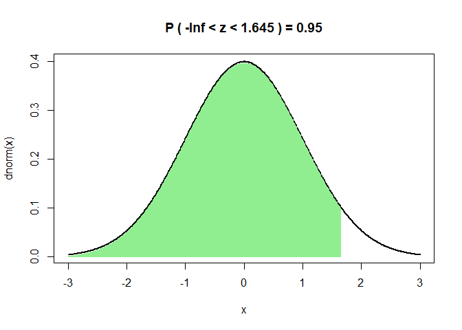

```r
##一个演示正态分布的样例
#注意，这个函数是自己编写的，而不是可以直接使用的
norm_st <- function(a = -Inf,b = Inf, lim = 3, digits = 3,col = 'lightgreen'){
  p = pnorm(b)-pnorm(a)
  x = seq(-lim,lim,by = 0.01)
  main = paste('P (',round(a,digits),'< z <',round(b,3),') =',round(p,digits))
  plot(x,dnorm(x),type = 'l', main = main,lwd = 2)
  seg = seq(max(-lim,a),min(lim,b),by = 0.01)
  segments(seg,0,seg,dnorm(seg)-0.003,col = col)
}

norm_st(b = 1.645)
```

```r
pnorm(1.645) #P(z<1.645)
```

```
## [1] 0.9500151
```

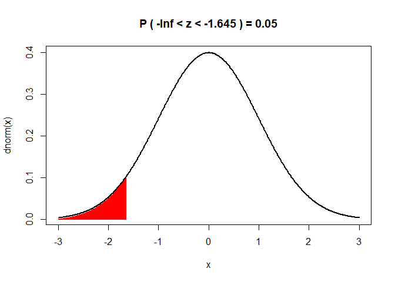

```r
norm_st(b = -1.645,col = 'red')
```

```r
pnorm(-1.645) #P(z<-1.645)
```

```
## [1] 0.04998491
```

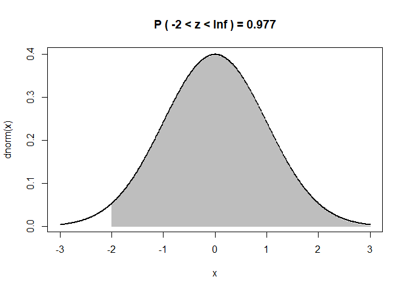

```r
norm_st(a = -2,col = 'grey')
```

```r
1- pnorm(-2) #P(z>-2)
```

```
## [1] 0.9772499
```

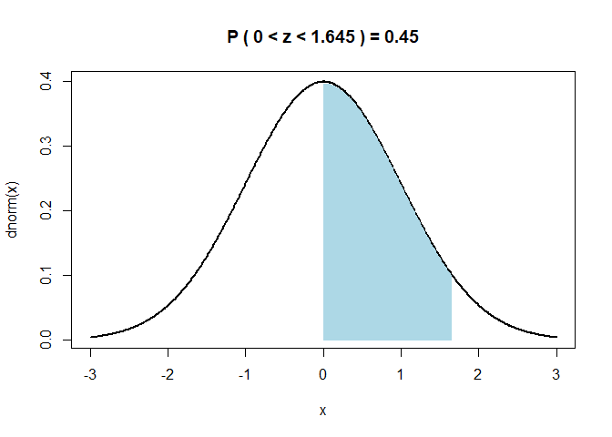

```r
norm_st(a = 0,b = 1.645, col = 'lightblue')
```

```r
pnorm(1.645) - pnorm(0) #P(0<z<1.645)
```

```
## [1] 0.4500151
```

```r
pnorm(c(-2,0,2))
```

```
## [1] 0.02275013 0.50000000 0.97724987
```

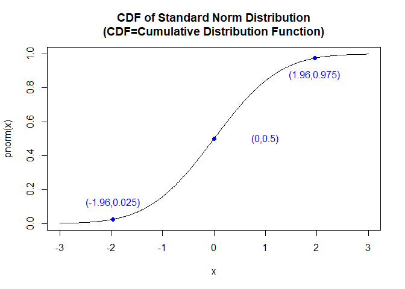

```r
x = seq(-3,3,0.01)
plot(x,pnorm(x),type = 'l',
     main = 'CDF of Standard Norm Distribution\n(CDF=Cumulative Distribution Function)')
points(c(1.96,0,-1.96),c(0.975,0.5,0.025), pch = 16, col = "blue")
text(c(1.96,1,-1.96),c(0.875,0.5,0.125), col = 'blue',
     label =c('(1.96,0.975)','(0,0.5)','(-1.96,0.025)'))
```

```r
qnorm(0.975) #使得P(z<a)=0.975的a，pnorm的反函数
```

```
## [1] 1.959964
```

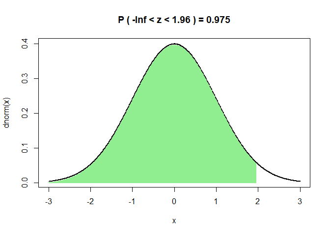

```r
norm_st(b = qnorm(0.975))
```